# Gov 1005 Pset 2

Ilyas Mardin

2/12/2020

## Mad Libs

1. The earliest date for an endorsement in the data set is 2017-07-28.
2. The most recent date for an endorsement in the data set is 2019-07-29.
3. Steve Adler is the mayor who has endorsed Pete Buttigieg.
4. Endorsers from New Hampshire have an average of 2.6 endorsement points.
5. Between them, the two female candidates remaining in the race (Elizabeth Warren and Amy Klobuchar), have a total of 72 endorsement points.
6. The type of data you are working with (words, numbers, categories, or fancier data types like dates) determines what kinds of operations you can perform on it. To distinguish different types of data, it’s useful tp use the function clas(). This function allows you to get to know what kind of data you’re working with.
1. The variable “position” is a factor class of variable.
2. The variable “endorser” is a character class of variable.
3. The variable “points” is a numeric class of variable.

## Put It Into Practice

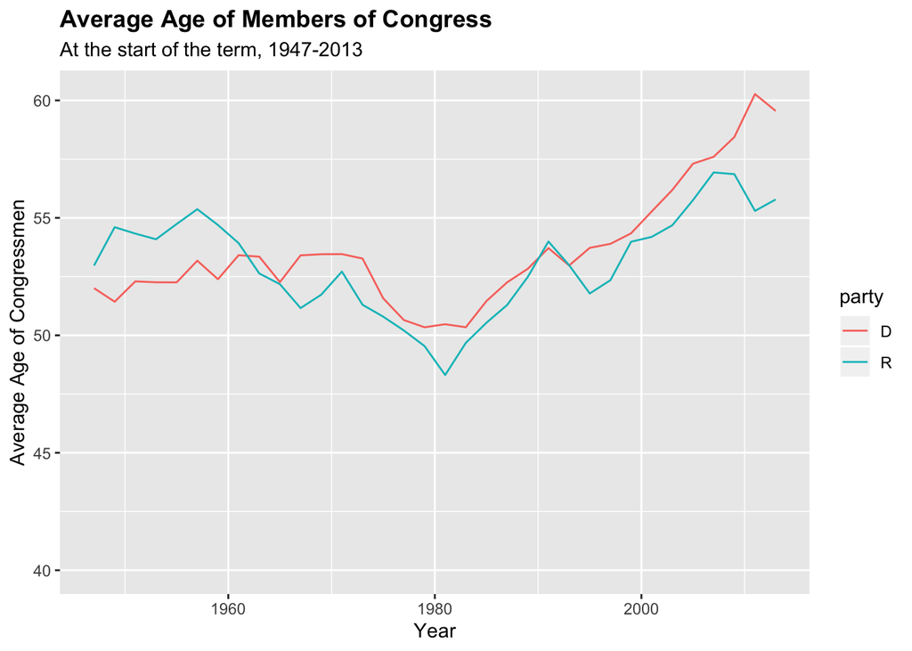

```r
age_data <- congress %>%
  filter(party %in% c("D", "R")) %>%
  group_by(year, party) %>%
  summarise(avg_age = mean(age))

ggplot(age_data, aes(year, avg_age, color = party)) +
  geom_line() + ggtitle("Average Age of Members of Congress", subtitle = "At the start of the term, 1947-2013") + expand_limits(x = 1950, y = 40) + scale_x_continuous() + scale_y_continuous() + labs(x = "Year", y = "Average Age of Congressmen") + theme(plot.title = element_text(face = "bold"))
```